# Ixora Coccinea

Juan Camilo Rojas

2026-09-03

## Ixora Coccinea

Se selecciona una especie de interes, la cual fue *Ixora coccinea*. Para observar sus ocurrencias a nivel global se necesita de una base de datos abierta, por esto. se utiliza Gbif, se observa si se encuentra la especie (figura1).

[figure not shown]

{#Figura 1. Interfase de GBIF para Ixora coccinea}

Para llevar a cabo el estudio de ocurrencias se utiliza el software de R studio, y se descargan los siguientes paquetes

```r
# Cargar librerias
library(tidyverse)
library(rgbif)
library(ggmap)
library(maps)
library(mapdata)
library(bdc)
library(CoordinateCleaner)
ixo <- occ_data(scientificName = "ixora coccinea")
```

Se trabajara a partir del paquete “rgbif” para obtener la matriz de ocurrencia, donde se especificara el nombre de la especie. Para Ixora coccinea la matriz tiene la siguiente estructura se observan las variables con las que cuenta la base de datos

```
##   [1] "key"
##   [2] "scientificName"
##   [3] "decimalLatitude"
##   [4] "decimalLongitude"
##   [5] "issues"
##   [6] "datasetKey"
##   [7] "publishingOrgKey"
##   [8] "datasetCategory"
##   [9] "installationKey"
##  [10] "hostingOrganizationKey"
##  [11] "publishingCountry"
##  [12] "protocol"
##  [13] "lastCrawled"
##  [14] "lastParsed"
##  [15] "crawlId"
```

[output cut: 92 more lines]

Se Verifican los problemas reportados y donde se encuentran estos problemas.

```
##           code                                             issue
## 1          bri                           BASIS_OF_RECORD_INVALID
## 2          ccm                        CONTINENT_COUNTRY_MISMATCH
## 3          cdc                CONTINENT_DERIVED_FROM_COORDINATES
## 4        conti                                 CONTINENT_INVALID
## 5         cdiv                                COORDINATE_INVALID
## 6        cdout                           COORDINATE_OUT_OF_RANGE
## 7        cdrep                            COORDINATE_REPROJECTED
## 8       cdrepf                    COORDINATE_REPROJECTION_FAILED
## 9       cdreps                COORDINATE_REPROJECTION_SUSPICIOUS
## 10     cdround                                COORDINATE_ROUNDED
## 11     cucdmis                       COUNTRY_COORDINATE_MISMATCH
## 12        cudc                  COUNTRY_DERIVED_FROM_COORDINATES
## 13        cuiv                                   COUNTRY_INVALID
## 14         cum                                  COUNTRY_MISMATCH
```

[output cut: 285 more lines]

```
##      code                              issue
## 1     cdc CONTINENT_DERIVED_FROM_COORDINATES
## 2 cdround                 COORDINATE_ROUNDED
## 3    cudc   COUNTRY_DERIVED_FROM_COORDINATES
##                                                                                   description
## 1 The interpreted continent is based on the coordinates, not the verbatim string information.
## 2                                     Original coordinate modified by rounding to 5 decimals.
## 3   The interpreted country is based on the coordinates, not the verbatim string information.
##         type
## 1 occurrence
## 2 occurrence
## 3 occurrence
```

Se seleccionan los campos de interes

```r
ixo1 <- ixo$data %>%
  dplyr::select(any_of(c(
    "scientificName", "acceptedScientificName", "decimalLatitude", "decimalLongitude",
    "issues", "country", "basisOfRecord", "occurrenceStatus",
    "datasetName", "recordedBy", "depth", "locality", "habitat")))
```

Se verifican las ocurrencias unicas

```r
ixo1 <- ixo1 %>%
  distinct()
```

Se revisan los niveles de los factores

```r
lapply(ixo1, unique)
```

```
## $scientificName
## [1] "Ixora coccinea Comm. ex Lam."
##
## $acceptedScientificName
## [1] "Ixora coccinea Comm. ex Lam."
##
## $decimalLatitude
##   [1]  18.332400  14.467119  19.067721  18.332010  18.330032  18.137708
##   [7]  18.155541  17.964687  12.075419   8.925715   7.926525  15.320892
##  [13]  14.768145   6.021240  18.276803  18.024633  18.334575  21.341620
##  [19]  14.540678  23.237773  18.137697  18.464194  14.557925   7.075545
##  [25]   6.062458  -8.673019  18.225570  18.137668  11.717180  18.094726
##  [31]  11.639363   5.322850 -12.102205  17.413012  15.694444   7.071650
##  [37]  -6.259605 -23.016456  18.405592   9.191345  19.907595  12.942872
##  [43]  18.234763  18.234288   8.536463  18.226056  22.647147  18.234427
```

[output cut: 652 more lines]

Se revisan las coordenadas y se eliminan los NAS, se da un limite a la variable.

```r
# checar coordenadas válidas
check_pf <-
  bdc::bdc_coordinates_outOfRange(
    data = ixo1,
    lat = "decimalLatitude",
    lon = "decimalLongitude")
```

```
##
## bdc_coordinates_outOfRange:
## Flagged 0 records.
## One column was added to the database.
```

```r
# Eliminar filas con NA o coordenadas fuera de rango
ixo1_valido <- ixo1 %>%
  filter(
    !is.na(decimalLatitude),
    !is.na(decimalLongitude),
    decimalLatitude >= -90 & decimalLatitude <= 90,
    decimalLongitude >= -180 & decimalLongitude <= 180)
```

Se realiza un filtro sobre los datos de las coordenadas para tener solo datos validos.

```r
cl <- ixo1_valido %>%
  CoordinateCleaner::clean_coordinates(
    species = "acceptedScientificName",
    lat = "decimalLatitude",
    lon = "decimalLongitude",
    tests = c("capitals", "centroids", "equal", "gbif", "institutions", "zeros")
  )
```

```
## Testing coordinate validity
```

```
## Flagged 0 records.
```

```
## Testing equal lat/lon
```

```
## Flagged 0 records.
```

```
## Testing zero coordinates
```

```
## Flagged 0 records.
```

```
## Testing country capitals
```

```
## Flagged 60 records.
```

```
## Testing country centroids
```

```
## Flagged 8 records.
```

```
## Testing GBIF headquarters, flagging records around Copenhagen
```

```
## Flagged 0 records.
```

```
## Testing biodiversity institutions
```

```
## Flagged 7 records.
```

```
## Flagged 72 of 491 records, EQ = 0.15.
```

Se observa la distribución de Ixora coccinea por medio de un mapa mundial.

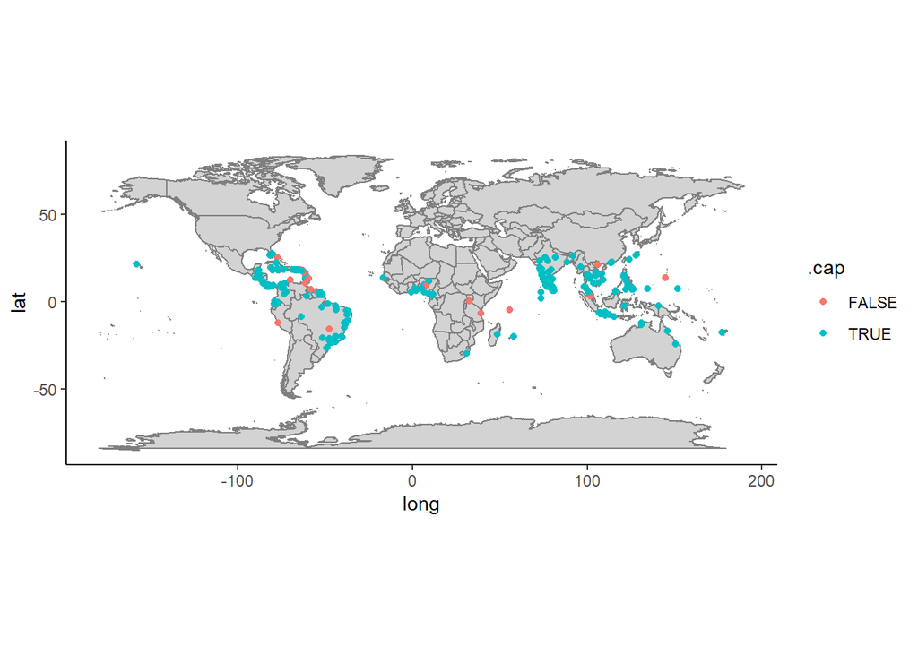

```r
ggplot() +
  borders("world", fill = "lightgray") +
  geom_point(data = cl, aes(x = decimalLongitude, y = decimalLatitude, color = `.cap`)) +
  coord_quickmap() +
  theme_classic()
```

Se observa todos los paises donde tiene ocurrencia

```r
ixo1 %>%
  distinct(country) %>%
  pull()
```

```
##  [1] "Virgin Islands (U.S.)"            "Philippines"
##  [3] "India"                            "Puerto Rico"
##  [5] "Colombia"                         "Martinique"
##  [7] "Sri Lanka"                        "United States of America"
##  [9] "Indonesia"                        "Peru"
## [11] "Thailand"                         "Brazil"
## [13] "Myanmar"                          "Costa Rica"
## [15] "Japan"                            "Australia"
## [17] "Suriname"                         "Nigeria"
## [19] "Dominica"                         "Saint Vincent and the Grenadines"
## [21] "Nicaragua"                        "Guam"
## [23] "Aruba"                            "Saint Lucia"
## [25] "Sint Maarten (Dutch part)"        "Benin"
## [27] "El Salvador"                      "Togo"
## [29] "Belize"                           "French Guiana"
```

[output cut: 18 more lines]

Se hace un plot para ver las ocurrencias en los distintos paises

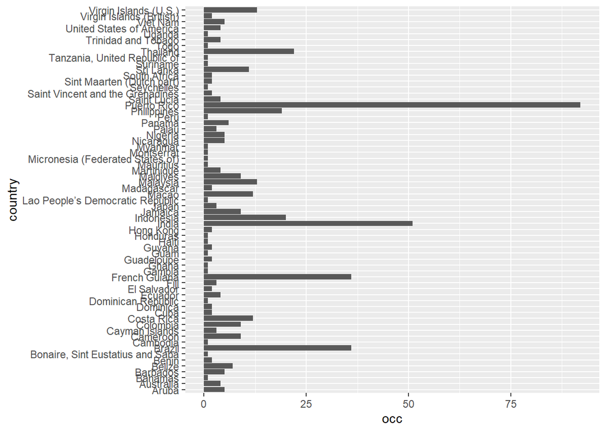

```r
# Country
ixo1 %>%
  group_by(country) %>%
  summarise(occ = length(scientificName)) %>%
  ggplot(aes(occ, y=country)) +
  geom_bar(stat = 'identity')
```

Debido al ruido que genera la imagen se hace una selección de su ocurrencia en sudamerica

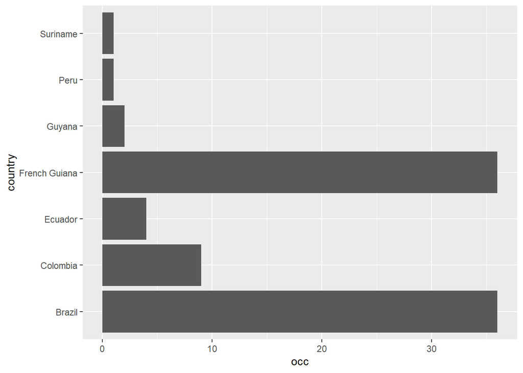

```r
ixo1 %>%
  filter(country %in% c("Colombia", "Peru", "Brazil", "Suriname",
                        "French Guiana", "Ecuador", "Guyana",
                        "Venezuela (Bolivarian Republic of)",
                        "Paraguay", "Argentina")) %>%
  group_by(country) %>%
  summarise(occ = length(scientificName)) %>%
  ggplot(aes(x = occ, y = country)) +
  geom_bar(stat = 'identity')
```